# Predicting Success for Olympic Track Athletes with a Multi-Level Model

Nick Browen, Eric Ortiz

=============================================================

Project Description:

http://statweb.calpoly.edu/bchance/stat414/Stat414Project.pdf

=============================================================

### Introduction

```
Still to do:
  1. Incorporate supporting references into text
```

Every four years, the Olympics Events garner worldwide attention much attention. We wanted to know what athlete characteristics contribute to their success and how the country they are from affects this. There is so much data readily available about the Olympics, even going back to 1896. We also were excited to be able to combine datasets and information from multiple resources from Olympic data to population and GDP of the countries of the world over time.

We chose to include athlete-level characteristics because the ideal physique for a distance runner is much different than a 100m sprinter and we think this will be useful in explaining differences in finishing time and are curious what other nuances will be revealed. At the country-level, we chose to include explanatory variables because athletes are sent as a team by their country and so the athlete pool, training resources and even quality of life might reveal some trends in predicting finishing times.

When looking through some literature on the subject, we came to realize that more is involved with success in the Olympics than just the variables at the athlete level such as height, weight, gender, and age. We were struck by Xun Bian’s paper titled “Predicting Olympic Medal Counts: the Effects of Economic Development on Olympic Performance” in which Olympic medal counts for a country were predicted from variables at the country level such as population, GDP, who the hosting country is, and whether the country is Socialist or not. Further, when we looked at the paper by Filippo Radicchi titled “Universality, Limits and Predictability of Gold-Medal Performances at the Olympic Games”, we could see that there is variablility at the athlete level since many athletes compete in more than one Olympics in their lifetime.

We chose to consider factors at both the athlete level and country level in a Hierarchical Model to predict the finishing time of track athletes.

##### Research Question

How can we best predict an Olympic track athlete’s finishing time? What is the relationship between an athlete’s finishing time and factors at the athlete level such as sex, age, weight, and height as well as factors at the country level such as the athlete’s nationality, their country’s GDP, and population?

**Chance’s Notes**: *I really like how you have athlete level variables and country level variables. But I do wonder if you need to “standardize” the response variable a bit? Nesting within event is good but still difficult to compare the times to each other? Would it be better to pick one event and look at multiple athletes from the same country over time?*

### Materials and Methods

```
Three to five paragraphs (or fewer) that…
  1. Briefly describe your data, where it came from (source), definitions of important variables,
     and how it was collected
  2. Indicate any modifications made to the data, recoding, or decisions about missing data
  3. Briefly but thoroughly describe the statistical inference methods used to quantify the
     association between your outcome and predictor variables in a multilevel analysis.
     What summary statistics were calculated?
     What statistical tests were performed?
  4. Specify strategies employed when building your models
  5. Do not report results in the Materials and Methods section!
```

Our data consist of merged datasets from Kaggle.com. First we found a comprehensive dataset of all Olympic medalists, but we subsetted this to include just track athletes that performed in running events (specifically the 10k race and all events shorter than 10k, not including events such as hurdles or steeple chase). This file contains info on athlete level characteristics such as height, weight, and age, but it did not include the finishing times. So we then merged this with another dataset from Kaggle that included finishing time. Then, from Gapminder.com we obtained country level information such as GDP and population and merged this into our dataset as well.

Having synthesized all these datasets together, we converted the event variable that would read like “100 M Men” into a quantitative variable that indicated the distance of the race. Finally, we rescaled the distance variable in order that the intercept would be about the 100m race. Similiarly, the year of the event was rescaled to be number of years since 1896. Height and weight were converted to BMI. Several variations of GDP and population of countries were tried out during the model building process. We first rescaled GDP as GDP in billions of dollars and, as indicated from our Exploratory Data Analysis, population was put on a log scale. GDP per capita (GDP/population) was also calculated. Later, GDP and population were categorized into “small”, “medium”, “large”, and GDP per capita was categorized into “low” and “high”. Throughout the model building process, log transformations of the distance of races and finishing times were calculated. All continous explanatory variables were centered, with the exclusion of distance and year.

To quantify the association between the finishing time of races and our predictor variables, we investigated these relationships at the athlete level and then at the country level. Correlation plots and correlation matrices were produced to identify predictor variables that were important to finishing time. To investigate interactions, plots of the finishing time versus a predictor variable were split into panels by another predictor variable were analyzed to determine if any relationships differs across another variable.

Initially, a two level random intercepts model was fit predicting finishing time (seconds) allowing the country the athlete is from to be the random. Quickly, we included the distance of the race as a predictor variable to account for the obvious variation in finishing times. Then, random slopes were included for distance. After verifying this was helpful, we added all predictor variables and interactions that our Exploratory Data Analysis indicated would be useful in predicting the finishing time. Then using t-tests, we systematically removed insignificant terms and refitted the model. Throughout this process is when several variables were converted into more useful variables such as height and weight into BMI, GDP into GDP into billions of dollars, and GDP per capita converted to a categorical variable. AIC and log-likelihood ratio tests were used to compare models. We briefly attempted log transformations on distance and finishing time, in an effort to remedy the effects of using distance (a somewhat categorical variable with large spacing between values) as a quantitative variable.

When merging these data sets together we also ran into missing values, namely for countries that were not included in Gapminder’s country GDP and Population data or countries that changed their name at some point (for example Soviet Union to Russia). Where possible, we were able to search out the countries that changed name and correct for that error. However, we chose to omit countries that we had no country-level data on.

### Results

```
The meat of your report, which should include…
  1. A general description of your data (completed via your exploratory data analysis)
  2. A description of the results from your analyses, including interpretations of parameter             estimates, tests, and confidence intervals in context.
  3. Tables that summarize results and figures that illustrate results. These tables and figures         should be well-labeled, numbered (e.g., Figure 1), and have a good, descriptive caption. Each       report should have a minimum of two plots; rarely are residual plots part of the main body of  …
  4. You should interpret tests, confidence intervals, and coefficients in this section, but you         should not editorialize here! Save that for the Discussion.
```

In our final data set, we ended up with:

- 585 total observations (completed track events by a medaling athlete)
- 410 total athletes
  - 177 from the USA
  - 54 from the UK
  - 45 from Jamaica
- 45 total countries

The following variables are used in our final model to predict `timeSecs`:

```r
mod13 <- lme(data = track,
            fixed = timeSecs ~ dist100 + c_BMI + year1896 + sex + sex*dist100 + gdpPerCap_ + gdpPerCap_*dist100,
            random = ~ dist100|country2)
summary(mod13)
```

```
Linear mixed-effects model fit by REML
 Data: track
```

|  | AIC | BIC | logLik |
| --- | --- | --- | --- |
|  | 5142.058 | 5194.352 | -2559.029 |

```
Random effects:
 Formula: ~dist100 | country2
 Structure: General positive-definite, Log-Cholesky parametrization
            StdDev       Corr
(Intercept) 12.288575987 (Intr)
dist100      0.009230628 -0.888
Residual    17.144606507

Fixed effects: timeSecs ~ dist100 + c_BMI + year1896 + sex + sex * dist100 +      gdpPerCap_ + gdpPerCap_ * dist100
```

|  | Value | Std.Error | DF | t-value | p-value |
| --- | --- | --- | --- | --- | --- |
| (Intercept) | 18.023258 | 4.595843 | 533 | 3.92164 | 1e-04 |
| dist100 | 0.162607 | 0.001903 | 533 | 85.44675 | 0e+00 |
| c_BMI | 4.903095 | 0.976202 | 533 | 5.02262 | 0e+00 |
| year1896 | -0.283504 | 0.036703 | 533 | -7.72431 | 0e+00 |
| sexW | 13.207413 | 2.308153 | 533 | 5.72207 | 0e+00 |
| gdpPerCap_low | -14.861155 | 2.592148 | 533 | -5.73314 | 0e+00 |
| dist100:sexW | 0.017582 | 0.000623 | 533 | 28.23421 | 0e+00 |
| dist100:gdpPerCap_low | 0.014111 | 0.000832 | 533 | 16.96308 | 0e+00 |

```
 Correlation:
                      (Intr) dst100 c_BMI  yr1896 sexW   gdpPC_ d100:W
dist100               -0.504
c_BMI                 -0.066  0.134
year1896              -0.759  0.040 -0.067
sexW                  -0.050  0.101  0.400 -0.242
gdpPerCap_low         -0.676  0.152  0.060  0.585  0.052
dist100:sexW           0.102 -0.097  0.015 -0.016 -0.410 -0.076
dist100:gdpPerCap_low  0.160 -0.264 -0.125 -0.015 -0.107 -0.400  0.043

Standardized Within-Group Residuals:
        Min          Q1         Med          Q3         Max
-2.93492975 -0.49713620 -0.02064896  0.40879775  6.47067979

Number of Observations: 585
Number of Groups: 45
```

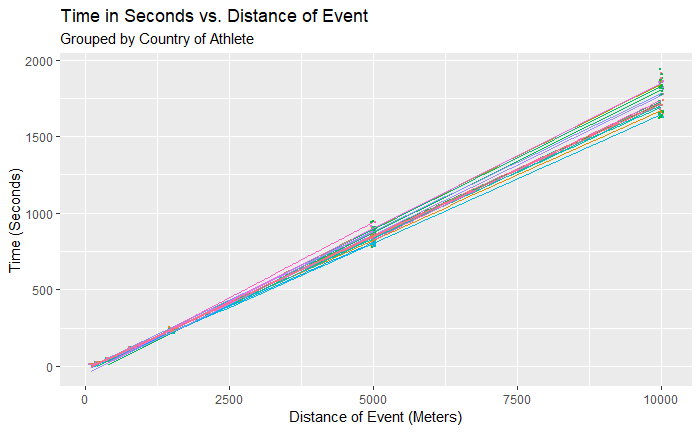

```r
ggplot(track, aes(y=timeSecs, x=dist, color = country2)) +
  geom_point(size = 0.5, position = "Jitter", show.legend = F) +
  geom_smooth(show.legend=F, se=F, size = 0.3, method = "lm") +
  labs(title = "Time in Seconds vs. Distance of Event",
       subtitle = "Grouped by Country of Athlete",
       y = "Time (Seconds)",
       x = "Distance of Event (Meters)")
```

### Discussion

[output not shown]

### Annotated Appendix

```
  1. Tables and figures that are informative but were not referenced specifically in the main            report.
     Include a short annotation – one or two sentences on what they show.
  2. Annotated output so that I can trace how you constructed your final data set, what models you       ran to produce the results quoted in your report, and what intermediate models you also             considered.
  3. Description of statistical modeling steps that were not included in the main body of your
     report.
     Possible entries here include:
      - How you handled missing data
      - Evaluation of assumptions.
      - Outlier analysis and how you decided to deal with any outliers along with rationale for your         decision.
      - Describe hypotheses testing you performed during model building and how you decided on the          explanatory variables you ultimately included in your final model.
      - Assessment of the final model.
  4. How you went from the model output in JMP/R to interpretations in your report
     (e.g. exponentiate coefficients, and then take inverse)
  5. Anticipate questions someone might have after reading your report, and make sure those              questions can be answered with information in the appendix.
  6. A citation for each reference article you included in your proposal. Also include a link, if        appropriate. Remember that you must have the entire paper and not just an abstract, and at          least two must be from peer-reviewed journals.
```

##### Citations

1. Radicchi F (2012) Universality, Limits and Predictability of Gold-Medal Performances at the Olympic Games.  
   https://doi.org/10.1371/journal.pone.0040335
2. Bian, X. 2005. Predicting Olympic Medal Counts: The Effects of Economic Development on Olympic Performance.  
   https://pdfs.semanticscholar.org/7293/1ab692bcab9e724b0e5ed4adb53b7ff8097f.pdf
3. Country Level Data such as GDP and Population.  
   https://www.gapminder.org/data/
4. Athlete Level Data for Finishing Time.  
   https://www.kaggle.com/jayrav13/olympic-track-field-results
5. Athlete Level Data for Height, Age, Sex, and Country.  
   https://www.kaggle.com/heesoo37/120-years-of-olympic-history-athletes-and-results